# Using `brms` and `traitintegration`

```r
library(traitintegration)
```

## Introduction

This vignette provides an overview of how to use `brms` to fit a Bayesian multiple response model to traits measured on individuals. The goal in doing so is to generate a posterior distribution for the correlation among traits. We can then use this posterior distribution in the `traitintegration` package to estimate the posterior distribution of the maximum eigenvalue, the variance of eigenvalues, and entR as measures of trait integration. We will use the wild population data from [Helianthome](http://www.helianthome.org/) as an example.

## Fitting a model with `brms`

First we retrieve the data from [Helianthome](http://www.helianthome.org/), store it in a data frame called `dat`, and retain only the columns `Leaf C N ratio`, `SLA`, `Primary branches`, `Stem diameter at flowering`, `Ligule length`, `Phyllaries length`, and `population_id`. Note: If you load the `readr` library, you don’t need the `readr::` prefix for the `read_csv()`.

```r
## retrieve the phenotype matrix
##
phenos <- readr::read_csv("http://www.helianthome.org/rest/population/phenotype_matrix/wild",
                          show_col_types = FALSE)
# ## retrieve the list of populations (for population_id)
# ##
# populations <- readr::read_csv("http://www.helianthome.org/rest/population/list/",
#                           show_col_types = FALSE)
## retrieve individual id and population id
##
index <- readr::read_csv("http://www.helianthome.org/rest/individual/list/",
                          show_col_types = FALSE)
## merge population id into phenotypic data
##
wild <- merge(phenos, index, by = "individual_id") |>
  dplyr::select(`Leaf C N ratio`, SLA, `Primary branches`,
                `Stem diameter at flowering`, `Ligule length`,
                `Phyllaries length`, population_id) |>
  dplyr::rename(Leaf.C.N.ratio = `Leaf C N ratio`,
                Primary.branches = `Primary branches`,
                Stem.diameter.at.flowering = `Stem diameter at flowering`,
                Ligule.length = `Ligule length`,
                Phyllaries.length = `Phyllaries length`)
```

Now that we have the data, we can fit a model using `brms`. Specifically, we will fit a model in which we simply fit a random intercept for each population. This means that the correlation matrix we estimate is the within-population covariance matrix. The lines begininng `wild_` define linear models with a random intercept for each of the six traits included in the analysis. They are combined into a single, multiresponse model using the `+` operator in the call to `brm`.

The `set_rescor(rescor = TRUE)` argument tells `brms` to estimate correlations among the traits. The `refresh = 0` prevents `brms` from telling us how many iterations it is completing. The `options(mc.cores = parallel::detectCores())` tells brms to use as many cores as you have (up to 4) to run the MCMC chains in parallel. Note: Just as above, if you load the`brms` library, you don’t need the `brms::` prefix for the calls to `bf()` and `brm()`.

```r
options(mc.cores= parallel::detectCores())

wild_CN <- brms::bf(Leaf.C.N.ratio ~ (1|population_id))
wild_SLA <- brms::bf(SLA ~ (1|population_id))
wild_branch <- brms::bf(Primary.branches ~ (1|population_id))
wild_stem <- brms::bf(Stem.diameter.at.flowering ~ (1|population_id))
wild_ligule <- brms::bf(Ligule.length ~ (1|population_id))
wild_phyllary <- brms::bf(Phyllaries.length ~ (1|population_id))

mod_wild <- brms::brm(wild_CN + wild_SLA + wild_branch + wild_stem +
                        wild_ligule + wild_phyllary +
                        brms::set_rescor(rescor = TRUE),
                      data = wild,
                      family = "gaussian",
                      refresh = 0)
```

`brms` will automatically exclude any individuals with missing data. Now that the model has finished, we can explore some of the results.

```r
summary(mod_wild)
```

```
#>  Family: MV(gaussian, gaussian, gaussian, gaussian, gaussian, gaussian)
#>   Links: mu = identity; sigma = identity
#>          mu = identity; sigma = identity
#>          mu = identity; sigma = identity
#>          mu = identity; sigma = identity
#>          mu = identity; sigma = identity
#>          mu = identity; sigma = identity
#> Formula: Leaf.C.N.ratio ~ (1 | population_id)
#>          SLA ~ (1 | population_id)
#>          Primary.branches ~ (1 | population_id)
#>          Stem.diameter.at.flowering ~ (1 | population_id)
#>          Ligule.length ~ (1 | population_id)
#>          Phyllaries.length ~ (1 | population_id)
#>    Data: wild (Number of observations: 530)
#>   Draws: 4 chains, each with iter = 2000; warmup = 1000; thin = 1;
#>          total post-warmup draws = 4000
#>
#> Multilevel Hyperparameters:
#> ~population_id (Number of levels: 62)
#>                                       Estimate Est.Error l-95% CI u-95% CI Rhat
#> sd(LeafCNratio_Intercept)                 0.65      0.12     0.42     0.89 1.00
#> sd(SLA_Intercept)                         2.17      0.43     1.31     3.05 1.00
#> sd(Primarybranches_Intercept)             6.79      0.68     5.63     8.29 1.00
#> sd(Stemdiameteratflowering_Intercept)     6.44      0.69     5.18     7.93 1.00
#> sd(Ligulelength_Intercept)                0.49      0.06     0.39     0.61 1.00
#> sd(Phyllarieslength_Intercept)            0.53      0.06     0.43     0.66 1.00
#>                                       Bulk_ESS Tail_ESS
#> sd(LeafCNratio_Intercept)                 1573     2503
#> sd(SLA_Intercept)                         1442     1472
#> sd(Primarybranches_Intercept)             1069     1908
#> sd(Stemdiameteratflowering_Intercept)     1174     1709
#> sd(Ligulelength_Intercept)                1696     2329
#> sd(Phyllarieslength_Intercept)            1041     2020
#>
#> Regression Coefficients:
#>                                   Estimate Est.Error l-95% CI u-95% CI Rhat
#> LeafCNratio_Intercept                 7.88      0.11     7.66     8.10 1.00
#> SLA_Intercept                        23.19      0.40    22.39    23.96 1.00
#> Primarybranches_Intercept            21.74      0.88    20.02    23.46 1.00
#> Stemdiameteratflowering_Intercept    34.39      0.88    32.65    36.09 1.00
```

[output cut: 64 more lines]

```
#> rescor(SLA,Stemdiameteratflowering)                  3395
#> rescor(Primarybranches,Stemdiameteratflowering)      3256
#> rescor(LeafCNratio,Ligulelength)                     3207
#> rescor(SLA,Ligulelength)                             3270
#> rescor(Primarybranches,Ligulelength)                 3203
#> rescor(Stemdiameteratflowering,Ligulelength)         3239
#> rescor(LeafCNratio,Phyllarieslength)                 3223
#> rescor(SLA,Phyllarieslength)                         2858
#> rescor(Primarybranches,Phyllarieslength)             3167
#> rescor(Stemdiameteratflowering,Phyllarieslength)     2978
#> rescor(Ligulelength,Phyllarieslength)                3302
#>
#> Draws were sampled using sampling(NUTS). For each parameter, Bulk_ESS
#> and Tail_ESS are effective sample size measures, and Rhat is the potential
#> scale reduction factor on split chains (at convergence, Rhat = 1).
```

## Visualizing the posterior correlation matrix

With the fitted model in hand, visualizing the correlation matrix is straightforward. If you store the result of the call to `plot_posterior_correlation()` in a variable, say `p`, you can print the posterior mean correlation matrix as shown below.

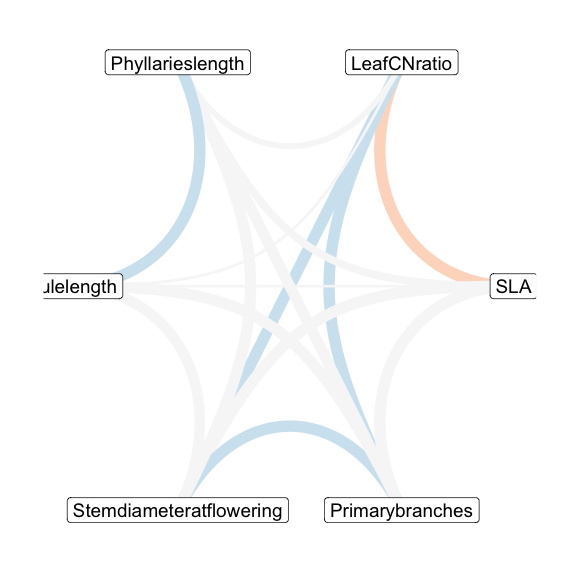

```r
p <- plot_posterior_correlation(mod_wild)
```

```r
print(p$R)
```

```
#>                         LeafCNratio         SLA Primarybranches
#> LeafCNratio              1.00000000 -0.36023696      0.32423435
#> SLA                     -0.36023696  1.00000000     -0.14472748
#> Primarybranches          0.32423435 -0.14472748      1.00000000
#> Stemdiameteratflowering  0.21977329 -0.12712371      0.35332146
#> Ligulelength             0.01656442 -0.01577509     -0.11847978
#> Phyllarieslength         0.04612757 -0.06200969     -0.09992245
#>                         Stemdiameteratflowering Ligulelength Phyllarieslength
#> LeafCNratio                          0.21977329   0.01656442       0.04612757
#> SLA                                 -0.12712371  -0.01577509      -0.06200969
#> Primarybranches                      0.35332146  -0.11847978      -0.09992245
#> Stemdiameteratflowering              1.00000000   0.09377997       0.13001835
#> Ligulelength                         0.09377997   1.00000000       0.36269402
#> Phyllarieslength                     0.13001835   0.36269402       1.00000000
```

The color of each edge reflects the posterior mean of the correlation coefficient for the nodes that are being connected, red for negative (< -0.2), blue for positive (> 0.2), or white for intermediate (-0.2 to 0.2). If you have correlation coefficients that are especially large in magnitude, they will display as more intense colors of red or blue.

You will probably find the labels at each node a bit long. If you do, you can use the `labels` argument to give them new names. If you’d also like to see values for the individual correlation coefficients, you can set the `label_edges` argument to `TRUE`. Note: storing the result of the call to `plot_posterior_correlation()` in `p` to suppresses printing of the posterior correlation matrix.

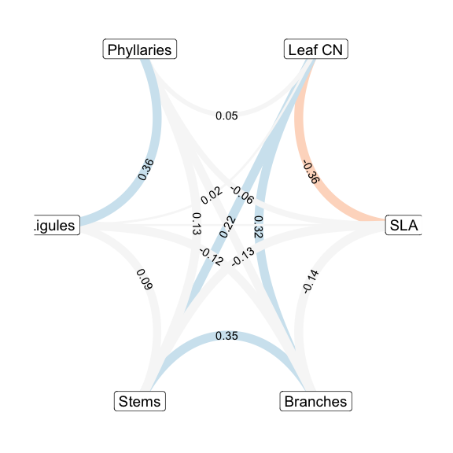

```r
p <- plot_posterior_correlation(mod_wild, labels = c("Leaf CN", "SLA", "Branches",
                                                     "Stems", "Ligules",
                                                     "Phyllaries"),
                           label_edges = TRUE)
```

If you look closely, you’ll notice that not all of the edges are labeled. That’s because some of those in the middle would overlap if they were displayed.

You aren’t stuck with the color palette used here. You can use any of the diverging color palettes in `RColorBrewer`. You can also change the number of digits displayed by using the `digits` argument.

## Estimating trait integration

Estimating trait integration is straightforward. We simply call the `assemble_statistics()` function with the fitted model as the argument. It is best to store the result in a variable, say `results`, so that you can work with the results.

```r
results <- assemble_statistics(mod_wild)
str(results)
```

```
#> 'data.frame':    4000 obs. of  9 variables:
#>  $ EV_1   : num  1.89 1.78 1.83 1.88 1.94 ...
#>  $ EV_2   : num  1.41 1.49 1.38 1.42 1.45 ...
#>  $ EV_3   : num  0.933 0.993 0.999 1.002 0.855 ...
#>  $ EV_4   : num  0.679 0.635 0.679 0.666 0.64 ...
#>  $ EV_5   : num  0.595 0.585 0.595 0.557 0.597 ...
#>  $ EV_6   : num  0.498 0.514 0.518 0.467 0.518 ...
#>  $ Lead_EV: num  1.89 1.78 1.83 1.88 1.94 ...
#>  $ Var_EV : num  0.295 0.279 0.266 0.311 0.327 ...
#>  $ ent_R  : num  0.265 0.263 0.253 0.279 0.275 ...
```

As you can see, `results` is a data frame in which the columns starting with `EV_` are the eigenvalues of the correlation matrix, `Lead_EV` is the lead eigenvalue, `Var_EV` is the variance of the eigenvalues, and `ent_R` the entropy measure of trait integration. The rows of the data frame correspond to samples from the posterior distribution.

You can summarize the results using the `summarize_statistics()` function.

```r
summarize_statistics(results)
```

```
#>   Statistic  Mean  2.5% 97.5%
#> 1   Lead_EV 1.801 1.651 1.956
#> 2    Var_EV 0.265 0.203 0.337
#> 3     ent_R 0.252 0.220 0.286
```

By default the data frame that is returned contains the posterior mean and the 2.5% and 97.5% quantiles of the statistic and rounds the results to 3 digits, but those options are easy to change.

```r
summarize_statistics(results, probs = c(0.025, 0.05, 0.5, 0.95, 0.975), digits = 2)
```

```
#>   Statistic Mean 2.5%   5%  50%  95% 97.5%
#> 1   Lead_EV 1.80 1.65 1.67 1.80 1.93  1.96
#> 2    Var_EV 0.27 0.20 0.21 0.26 0.32  0.34
#> 3     ent_R 0.25 0.22 0.22 0.25 0.28  0.29
```

You can also visualize the posterior distribution of any column using functions from the `bayesplot` package. For example, you can visualize the posterior distributions of the lead eigenvalue, variance of eigenvalues, and entR as follows (and as before, you can leave off the `bayesplot::` and ``ggplot2::` prefixes if you’ve loaded those libraries):

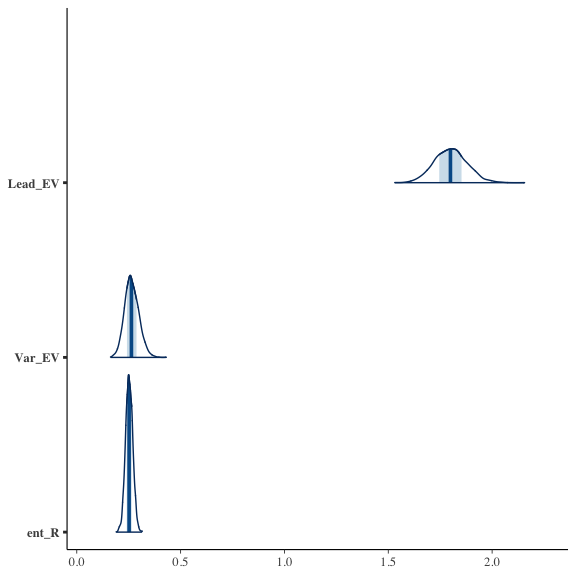

```r
bayesplot::mcmc_areas(results[, c("Lead_EV", "Var_EV", "ent_R")])
```

Note: You will only be able to use `bayesplot` functions that expect all chains to be merged, e.g., `mcmc_areas()`, `mcmc_intervals()`, mcmc_hist()`, and`mcmc_dens()`.

[interactive chart not shown]